# Rossi_Ansur lanjutan III

## Importing the libraries

```python
import pandas as pd
import matplotlib.pyplot as plt
import seaborn as sns
import numpy as np
import lifelines
from lifelines import KaplanMeierFitter
from lifelines.statistics import logrank_test
from sklearn.calibration import calibration_curve

import warnings
warnings.filterwarnings("ignore")
plt.style.use('seaborn')
```

## Importing the dataset

```python
from lifelines.datasets import load_rossi
df = load_rossi()
df.head()
```

|  | week | arrest | fin | age | race | wexp | mar | paro | prio |
| --- | --- | --- | --- | --- | --- | --- | --- | --- | --- |
| 0 | 20 | 1 | 0 | 27 | 1 | 0 | 0 | 1 | 3 |
| 1 | 17 | 1 | 0 | 18 | 1 | 0 | 0 | 1 | 8 |
| 2 | 25 | 1 | 0 | 19 | 0 | 1 | 0 | 1 | 13 |
| 3 | 52 | 0 | 1 | 23 | 1 | 1 | 1 | 1 | 1 |
| 4 | 52 | 0 | 0 | 19 | 0 | 1 | 0 | 1 | 3 |

- **Week** : week of first arrest after release or censoring; all censored observations are censored at 52 weeks
- **arrest** : 1 if arrested, 0 if not arrested
- **fin (financial aid)** : 1 if yes, 0 if no
- **race** : 1 if black, 0 if non
- **wexp (full time work exp before incarceration)** : 1 if yes, 0 if no
- **paro (released on parole)** : 1 if yes, 0 if no
- **prio (number of convictions prior to current incarceration)**

## Feature Engineering & EDA

```python
df.info()
```

```
<class 'pandas.core.frame.DataFrame'>
RangeIndex: 432 entries, 0 to 431
Data columns (total 9 columns):
week      432 non-null int64
arrest    432 non-null int64
fin       432 non-null int64
age       432 non-null int64
race      432 non-null int64
wexp      432 non-null int64
mar       432 non-null int64
paro      432 non-null int64
prio      432 non-null int64
dtypes: int64(9)
memory usage: 30.5 KB
```

```python
df['prio'].value_counts()
```

```
1     113
2     100
3      58
4      43
0      38
5      26
6      11
8       9
10      8
7       6
11      6
9       5
12      2
13      2
14      2
18      2
15      1
Name: prio, dtype: int64
```

```python
df['age'].value_counts()
```

```
20    61
22    41
19    39
21    38
24    37
23    35
25    24
18    21
26    18
28    13
30    12
27    12
29    11
36     8
32     8
17     6
31     6
40     6
42     6
33     5
38     5
43     4
34     3
35     3
37     3
39     3
44     3
41     1
Name: age, dtype: int64
```

```python
def prio_count(x):
    if x >5:
        return '>5 convictions'
    else:
        return '<5 convictions'
def age_groups(x):
    if x<30:
        return 'less than 30'
    else:
        return 'more than 30'


df['prio_cat'] = df['prio'].apply(lambda x:prio_count(x))
df['new_age_group'] = df['age'].apply(lambda x:age_groups(x))
```

```python
df['new_age_group'].value_counts()
```

```
less than 30    356
more than 30     76
Name: new_age_group, dtype: int64
```

### Visualize the numerical features

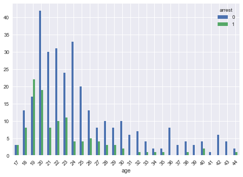

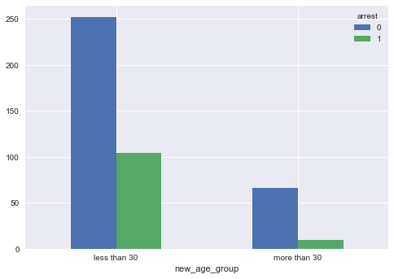

```python
num_plot1 = df.groupby(['age','arrest']).size().reset_index().pivot(columns='arrest',index='age',values=0)
num_plot1.plot.bar(stacked=False,rot=45)


num_plot2 = df.groupby(['new_age_group','arrest']).size().reset_index().pivot(columns='arrest',index='new_age_group',values=0)
num_plot2.plot.bar(stacked=False,rot=0)
```

berdasarkan visualisasi dari kolom 'age', **kelompok usia 19 hingga 23 tahun** merupakan yang paling banyak kembali masuk penjara dibandingkan dengan usia lain.

```python
df.columns
```

```
Index(['week', 'arrest', 'fin', 'age', 'race', 'wexp', 'mar', 'paro', 'prio',
       'prio_cat', 'new_age_group'],
      dtype='object')
```

## Visualize the categorical features

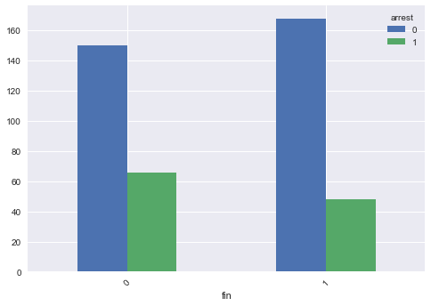

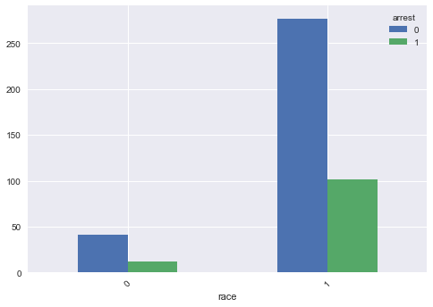

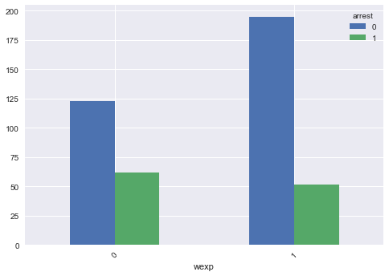

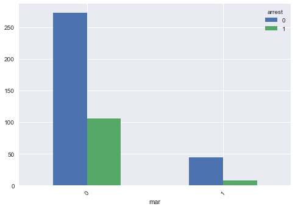

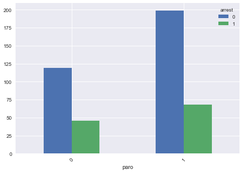

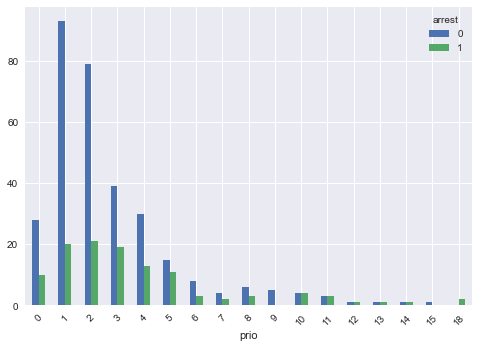

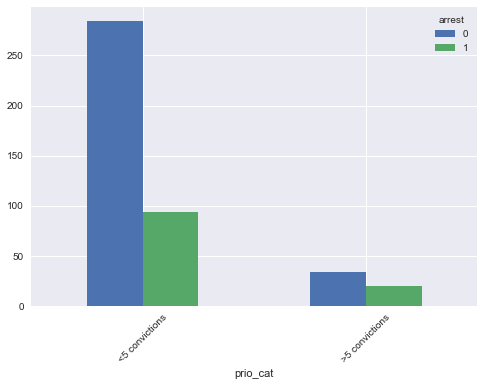

```python
columns_to_visualise = ['fin','race', 'wexp', 'mar', 'paro', 'prio','prio_cat']

for column in columns_to_visualise:
    plot_data = df.groupby([column, 'arrest']).size().reset_index().pivot(columns='arrest', index=column, values=0)
    plot_data.plot.bar(stacked=False, rot = 45)

plt.show()
```

## Checking for multicollinearity

```python
### Check for multicollinearity as it is a basic assumption of the CPH model
from statsmodels.stats.outliers_influence import variance_inflation_factor

# creating dummies for gender
# the independent variables set
X = df[['week', 'arrest', 'fin', 'age', 'race', 'wexp', 'mar', 'paro', 'prio']]

# VIF dataframe
vif_data = pd.DataFrame()
vif_data["feature"] = X.columns

# calculating VIF for each feature
vif_data["VIF"] = [variance_inflation_factor(X.values, i)
                          for i in range(len(X.columns))]

print(vif_data)
```

```
  feature        VIF
0    week  14.785227
1  arrest   1.994262
2     fin   2.032958
3     age  15.111121
4    race   7.455454
5    wexp   3.003476
6     mar   1.247794
7    paro   2.618238
8    prio   2.201653
```

Feature **age** memiliki multicollinearity dengan feature **week**, maka akan kita lakukan binning

```python
df.columns
```

```
Index(['week', 'arrest', 'fin', 'age', 'race', 'wexp', 'mar', 'paro', 'prio',
       'prio_cat', 'new_age_group'],
      dtype='object')
```

```python
from sklearn.preprocessing import LabelEncoder
LE = LabelEncoder()
df['new_age_group'] = LE.fit_transform(df['new_age_group'])
df['prio_cat'] = LE.fit_transform(df['prio_cat'])
```

```python
### Check for multicollinearity as it is a basic assumption of the CPH model
from statsmodels.stats.outliers_influence import variance_inflation_factor

# creating dummies for gender
# the independent variables set
X = df[['week', 'arrest', 'fin', 'age', 'race', 'wexp', 'mar', 'paro', 'prio',
       'prio_cat', 'new_age_group']]

# VIF dataframe
vif_data = pd.DataFrame()
vif_data["feature"] = X.columns

# calculating VIF for each feature
vif_data["VIF"] = [variance_inflation_factor(X.values, i)
                          for i in range(len(X.columns))]

print(vif_data)
```

```
          feature        VIF
0            week  20.948344
1          arrest   2.446315
2             fin   2.034858
3             age  37.755076
4            race   7.901200
5            wexp   3.011652
6             mar   1.251023
7            paro   2.680270
8            prio   6.570266
9        prio_cat   3.593911
10  new_age_group   3.246859
```

```python
df.drop(columns='age',inplace=True)
```

**aman**

## Kaplan Meier Curve

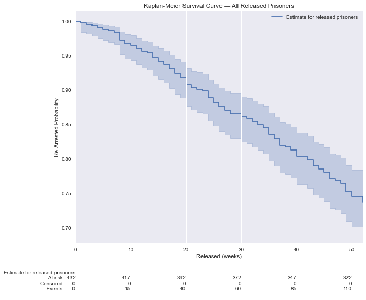

```python
kmf = KaplanMeierFitter()

# Fitting KMF to our data
kmf.fit(durations = df['week'], event_observed = df['arrest'],label = 'Estimate for released prisoners')

# plotting the KMF curve
fig,ax = plt.subplots(figsize=(10,8))
kmf.plot(at_risk_counts = True,ax=ax)
ax.set_title('Kaplan-Meier Survival Curve — All Released Prisoners')
ax.set_xlabel('Released (weeks)')
ax.set_ylabel('Re-Arrested Probability')
ax.grid();
```

### Kaplan Meier Curves for cohorts

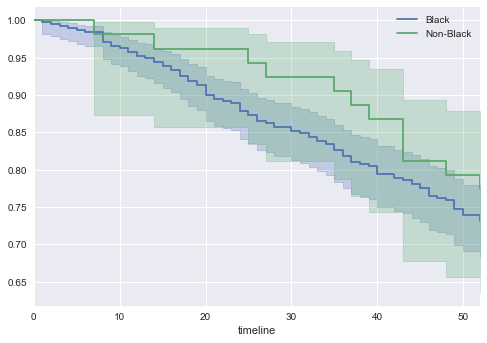

```python
kmf = KaplanMeierFitter()
T = df['week'] ## Time to event
E = df['arrest'] ## Event occured or censored

groups = df['race'] ## Create the cohorts from the 'Contracts' column
ix1 = (groups==1) # Cohort 1
ix2 = (groups==0)       # Cohort 2
kmf.fit(T[ix1],E[ix1],label ='Black') # fit the cohort 1 data
ax = kmf.plot()

kmf.fit(T[ix2],E[ix2],label ='Non-Black') # fit the cohort 2 data
ax1 = kmf.plot(ax=ax)

#Plot the KaplanMeier curve for three cohort on same x and y axis
```

### Plot another KMF Curve for another Cohorts

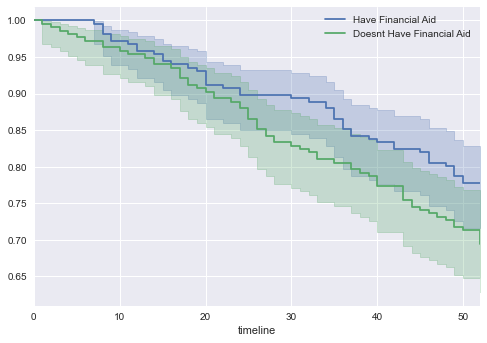

```python
kmf = KaplanMeierFitter()
T = df['week'] ## Time to event
E = df['arrest'] ## Event occured or censored

groups = df['fin'] ## Create the cohorts from the 'Contracts' column
ix1 = (groups==1) # Cohort 1
ix2 = (groups==0)       # Cohort 2
kmf.fit(T[ix1],E[ix1],label ='Have Financial Aid') # fit the cohort 1 data
ax = kmf.plot()

kmf.fit(T[ix2],E[ix2],label ='Doesnt Have Financial Aid') # fit the cohort 2 data
ax1 = kmf.plot(ax=ax)

#Plot the KaplanMeier curve for three cohort on same x and y axis
```

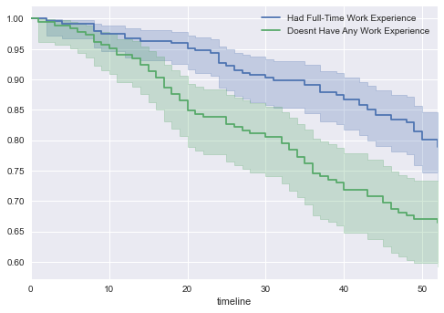

```python
kmf = KaplanMeierFitter()
T = df['week'] ## Time to event
E = df['arrest'] ## Event occured or censored

groups = df['wexp'] ## Create the cohorts from the 'Contracts' column
ix1 = (groups==1) # Cohort 1
ix2 = (groups==0)       # Cohort 2
kmf.fit(T[ix1],E[ix1],label ='Had Full-Time Work Experience') # fit the cohort 1 data
ax = kmf.plot()

kmf.fit(T[ix2],E[ix2],label ='Doesnt Have Any Work Experience') # fit the cohort 2 data
ax1 = kmf.plot(ax=ax)

#Plot the KaplanMeier curve for three cohort on same x and y axis
```

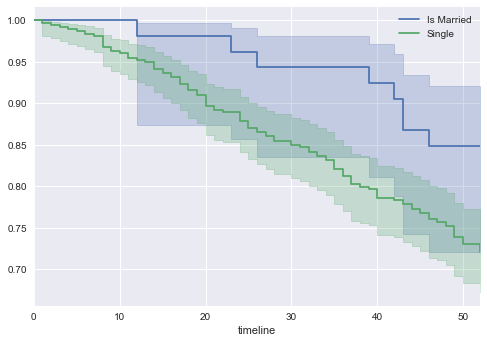

```python
kmf = KaplanMeierFitter()
T = df['week'] ## Time to event
E = df['arrest'] ## Event occured or censored

groups = df['mar'] ## Create the cohorts from the 'Contracts' column
ix1 = (groups==1) # Cohort 1
ix2 = (groups==0)       # Cohort 2
kmf.fit(T[ix1],E[ix1],label ='Is Married') # fit the cohort 1 data
ax = kmf.plot()

kmf.fit(T[ix2],E[ix2],label ='Single') # fit the cohort 2 data
ax1 = kmf.plot(ax=ax)

#Plot the KaplanMeier curve for three cohort on same x and y axis
```

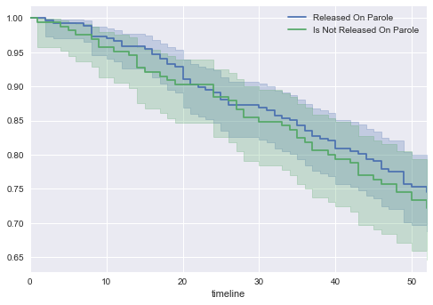

```python
kmf = KaplanMeierFitter()
T = df['week'] ## Time to event
E = df['arrest'] ## Event occured or censored

groups = df['paro'] ## Create the cohorts from the 'Contracts' column
ix1 = (groups==1) # Cohort 1
ix2 = (groups==0)       # Cohort 2
kmf.fit(T[ix1],E[ix1],label ='Released On Parole') # fit the cohort 1 data
ax = kmf.plot()

kmf.fit(T[ix2],E[ix2],label ='Is Not Released On Parole') # fit the cohort 2 data
ax1 = kmf.plot(ax=ax)

#Plot the KaplanMeier curve for three cohort on same x and y axis
```

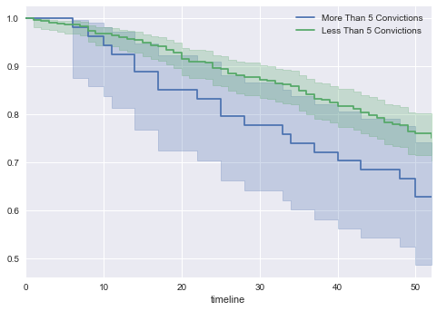

```python
kmf = KaplanMeierFitter()
T = df['week'] ## Time to event
E = df['arrest'] ## Event occured or censored

groups = df['prio_cat'] ## Create the cohorts from the 'Contracts' column
ix1 = (groups==1) # Cohort 1
ix2 = (groups==0)       # Cohort 2
kmf.fit(T[ix1],E[ix1],label ='More Than 5 Convictions') # fit the cohort 1 data
ax = kmf.plot()

kmf.fit(T[ix2],E[ix2],label ='Less Than 5 Convictions') # fit the cohort 2 data
ax1 = kmf.plot(ax=ax)

#Plot the KaplanMeier curve for three cohort on same x and y axis
```

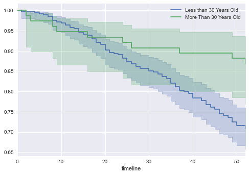

```python
kmf = KaplanMeierFitter()
T = df['week'] ## Time to event
E = df['arrest'] ## Event occured or censored

groups = df['new_age_group'] ## Create the cohorts from the 'Contracts' column

ix1 = (groups==0) # Cohort 1
ix2 = (groups==1) # Cohort 2
kmf.fit(T[ix1],E[ix1],label ='Less than 30 Years Old') # fit the cohort 1 data
ax = kmf.plot()

kmf.fit(T[ix2],E[ix2],label ='More Than 30 Years Old') # fit the cohort 2 data
ax1 = kmf.plot(ax=ax)


#Plot the KaplanMeier curve for three cohort on same x and y axis
```